# BL40A2030 Wireless Communication Networks

## Final work

### Author: Jesse Peltola

```python
import numpy as np
import matplotlib.pyplot as plt
import sympy as sp
from sympy.codegen.cfunctions import log2
import spicy as ss
from matplotlib import style
import math
#Not to show warning messages (to keep the notebook clean)
import warnings
warnings.filterwarnings('ignore')
style.use("bmh")
```

**The goal of the final work is to compute the Transmission Capacity (i.e. the highest achievable Spatial Throughput considering a maximum acceptable outage probability constraint), also considering aspects related to queue stability. The final work will be step-by-step.**

Consider a bipolar network similar to the one presented in weeks 6 and 7, but now considering a slotted-ALOHA-style of medium access.

- Network density $\lambda>0$
- Path-loss exponent $\alpha>2$
- Rayleigh fading, leading to a constant $\kappa$
- SIR threshold $\beta>0$
- TX-RX distance $d\geq1$
- Slotted Aloha access probability (independent for individual TXs): $p$
- Outage probability = 1 - success probability: $1 - e^{- \kappa p \lambda \pi d^2 \beta^{2/\alpha}} = 1 - P_s$
- Spatial throughput: $p \times \lambda \times P_s \times \log_2(1+\beta)$
- Maximum acceptable outage probability: $\epsilon$

*Note: When the slotted-ALOHA-style MAC is used, the original Poisson point process is thinned and the process of active transmitters in the networks becomes $p\lambda$ active nodes per square-meter.*

(A) Plot: $p \times \lambda \times P_s \times \log_2(1+\beta)$ in terms of the access probability $p$, considering that $P_s = 1-\epsilon$. Assume: $\alpha=4$, $d=1$, $\epsilon = 0.05$ and $\lambda=0.02$.

*Hint: First proceed with the algebraic manipulation of $P_s = 1-\epsilon$ to find the value of $\beta$ as a function of the other variables. Then, you ended up in a new equation.*

Lets solve the $\beta$

$1 - e^{- \kappa p \lambda \pi d^2 \beta^{2/\alpha}} = 1 - P_s$

$1 - e^{- \kappa p \lambda \pi d^2 \beta^{2/\alpha}} = 1 - (1 - \epsilon)$

$e^{- \kappa p \lambda \pi d^2 \beta^{2/\alpha}} = 1 - \epsilon $

$-\kappa p \lambda \pi d^2 \beta^{2/\alpha} = \ln(1-\epsilon)$

$ \beta = (-\dfrac{\ln(1-\epsilon)}{\kappa p \lambda \pi d^2})^{\alpha/2}$

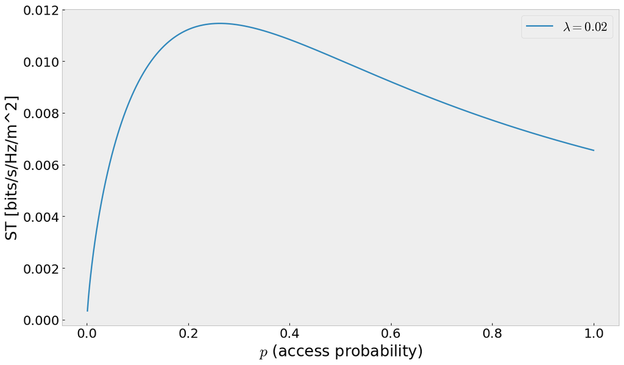

```python
#Path-loss exponent
alpha = 4
#lambda
lamb = 0.02
#epsilion
eps = 0.05
#distance
d = 1
#Success probability
P_s = 1 - eps
#p
p = np.linspace(0, 1, 1000)
#converting to sp
p_matrix = sp.Matrix(p)
#k
kappa = math.gamma(1 + 2/alpha) * math.gamma(1- 2/alpha)
beta = (np.log(1-eps)/-(kappa*p*lamb*np.pi*d**2))**(alpha/2)
ST = p * lamb * P_s * np.log2(1 + beta)


plt.rcParams.update({'font.size': 18})
plt.figure(figsize=(14,8))
plt.plot(p, ST, '-' , label=fr'$\lambda={lamb}$')

plt.xlabel("$p$ (access probability)")
plt.ylabel("ST [bits/s/Hz/m^2]")
plt.grid()
plt.legend()
plt.show()
```

(B) Find the value of $p$ that optimizes the spatial throughput.

*Hint: It might be possible that sympy cannot find the equation analytically so a numerical solution is also acceptable (see tutorial from week 7).*

```python
sp.init_printing()
d2, lamb2, beta2, alpha2, kappa2, eps2, p2, pi2, ps2 = sp.symbols('d lambda beta alpha kappa epsilon p pi P_s', real = True, positive = True)

beta = (sp.ln(1-eps2)/-(kappa2*p2*lamb2*pi2*d2**2))**(alpha2/2)
display(beta)

SP = p2 * lamb2 * ps2 * sp.log(1+beta, 2)
display(SP)
```

$\displaystyle \left(- \frac{\log{\left(1 - \epsilon \right)}}{d^{2} \kappa \lambda p \pi}\right)^{\frac{\alpha}{2}}$

$\displaystyle \frac{P_{s} \lambda p \log{\left(\left(- \frac{\log{\left(1 - \epsilon \right)}}{d^{2} \kappa \lambda p \pi}\right)^{\frac{\alpha}{2}} + 1 \right)}}{\log{\left(2 \right)}}$

```python
def solve_p_opt_aux(IE, alpha, kappa, lamb, d, P_s, eps):
    return IE.subs(alpha2, alpha).subs(kappa2, kappa).subs(lamb2, lamb).subs(d2, d).subs(ps2, P_s).subs(eps2, eps).subs(pi2, np.pi)
```

```python
#derivate
IE = sp.simplify(sp.diff(SP, p2))
display(IE)
```

$\displaystyle \frac{P_{s} \lambda \left(- \alpha \left(- \log{\left(1 - \epsilon \right)}\right)^{\frac{\alpha}{2}} + 2 \left(\left(- \log{\left(1 - \epsilon \right)}\right)^{\frac{\alpha}{2}} + \left(d \sqrt{\kappa} \sqrt{\lambda} \sqrt{p} \sqrt{\pi}\right)^{\alpha}\right) \log{\left(d^{- \alpha} \kappa^{- \frac{\alpha}{2}} \lambda^{- \frac{\alpha}{2}} p^{- \frac{\alpha}{2}} \pi^{- \frac{\alpha}{2}} \left(d^{\alpha} \kappa^{\frac{\alpha}{2}} \lambda^{\frac{\alpha}{2}} p^{\frac{\alpha}{2}} \pi^{\frac{\alpha}{2}} + \left(- \log{\left(1 - \epsilon \right)}\right)^{\frac{\alpha}{2}}\right) \right)}\right)}{2 \left(\left(- \log{\left(1 - \epsilon \right)}\right)^{\frac{\alpha}{2}} + \left(d^{2} \kappa \lambda p \pi\right)^{\frac{\alpha}{2}}\right) \log{\left(2 \right)}}$

```python
# p_opt = sp.solveset(sp.diff(SP, p2), p2)
# display(p_opt)

p_opt_aux = sp.nsolve(solve_p_opt_aux(IE, alpha, kappa, lamb, d, P_s, eps), p2, 0.1)
p_opt_np = sp.lambdify([],p_opt_aux,"numpy")
print(f'Max Value of P: {p_opt_np()}')
```

```
Max Value of P: 0.262441050926558
```

(C) Test the result from (B) using the numerical values from (A) by making the plot including the optimal spatial throuhgput value. Verify also for $\lambda=0.01$ and $\lambda=0.025$.

```
Max Value of P: 0.262441050926558
Max Value of P: 0.524882101853116
Max Value of P: 0.209952840741247
```

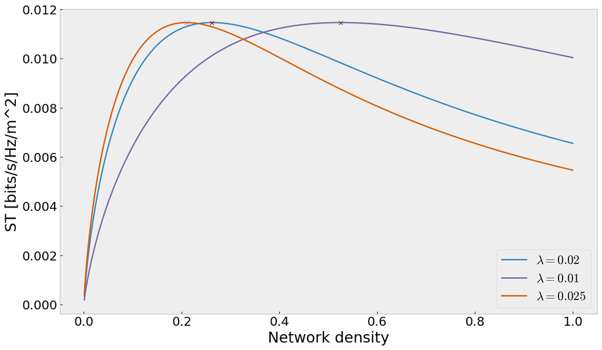

```python
plt.rcParams.update({'font.size': 18})
plt.figure(figsize=(14,8))

#lambda = 0.02
lamb = 0.02
p_opt_aux = sp.nsolve(solve_p_opt_aux(IE, alpha, kappa, lamb, d, P_s, eps), p2, 0.2)
p_opt_np_aux = sp.lambdify([], p_opt_aux, "numpy")
p_opt_np = p_opt_np_aux()
print(f'Max Value of P: {p_opt_np}')
p_e = p_opt_np

beta = (np.log(1-eps)/-(kappa*p*lamb*np.pi*d**2))**(alpha/2)
ST = p * lamb * P_s * np.log2(1 + beta)

beta_opt = (np.log(1-eps)/-(kappa*p_opt_np*lamb*np.pi*d**2))**(alpha/2)
plt.plot(p, ST, '-', label=fr"$\lambda={lamb}$")
plt.plot(p_opt_np_aux(), p_opt_np_aux() * lamb * P_s * np.log2(1+beta_opt), "x")

# #lambda = 0.01
lamb = 0.01
p_opt_aux = sp.nsolve(solve_p_opt_aux(IE, alpha, kappa, lamb, d, P_s, eps), p2, 0.2)
p_opt_np_aux = sp.lambdify([], p_opt_aux, "numpy")
p_opt_np = p_opt_np_aux()
print(f'Max Value of P: {p_opt_np}')


beta = (np.log(1-eps)/-(kappa*p*lamb*np.pi*d**2))**(alpha/2)
ST = p * lamb * P_s * np.log2(1 + beta)

beta_opt = (np.log(1-eps)/-(kappa*p_opt_np*lamb*np.pi*d**2))**(alpha/2)
plt.plot(p, ST, '-', label=fr"$\lambda={lamb}$")
plt.plot(p_opt_np_aux(), p_opt_np_aux() * lamb * P_s * np.log2(1+beta_opt), "x")

# #lambda = 0.025
lamb = 0.025
p_opt_aux = sp.nsolve(solve_p_opt_aux(IE, alpha, kappa, lamb, d, P_s, eps), p2, 0.2)
p_opt_np_aux = sp.lambdify([], p_opt_aux, "numpy")
p_opt_np = p_opt_np_aux()
print(f'Max Value of P: {p_opt_np}')


beta = (np.log(1-eps)/-(kappa*p*lamb*np.pi*d**2))**(alpha/2)
ST = p * lamb * P_s * np.log2(1 + beta)

beta_opt = (np.log(1-eps)/-(kappa*p_opt_np*lamb*np.pi*d**2))**(alpha/2)
plt.plot(p, ST, '-', label=fr"$\lambda={lamb}$")
plt.plot(p_opt_np_aux(), p_opt_np_aux() * lamb * P_s * np.log2(1+beta_opt), "x")

plt.xlabel("Network density")
plt.ylabel("ST [bits/s/Hz/m^2]")
plt.grid()
plt.legend()
plt.show()
```

(D) What is the transmission capacity of this network (i.e. the maximum achievable spatial throughput)?

```python
beta_opt = (np.log(1-eps)/-(kappa*p_opt_np*lamb*np.pi*d**2))**(alpha/2)
max_st = p_opt_np * lamb * P_s * np.log2(1+ beta_opt)
print(f'The transmission capacity of this network is : {max_st} bits/s/Hz/m^2')
```

```
The transmission capacity of this network is : 0.011464255080332308 bits/s/Hz/m^2
```

(E) Consider that the TXs have one queue where packets arrive at each time slot with a given probability $q$ (Bernoulli arrivals). What is the necessary relation between $p$ and $q$ that guarantees queue stability (i.e. the queue size is not growing to infinity with time). To answer this question you need to simulate this queue considering 3 conditions (i) $q<p$ by setting $q = p - 0.1$, (ii) $q=p$ and (iii) $q>p$ by setting $q = p + 0.1$ for the value of $p$ found in (B) for 10000 time-slots (time-steps) and evaluate the worst case delay.

*Hint: The packets will arrive with probability $q$ each time slot, while packets will leave with probability $p$ (similar to thowning a coin experiment with biased probability). This queue is similar to the "naive" simple queue approach taken in week 1 but now with Bernoulli arrivals and departures. To generate a sequence of Bernoulli, you can use the Binomial random number generator (numpy.random.binomial).*

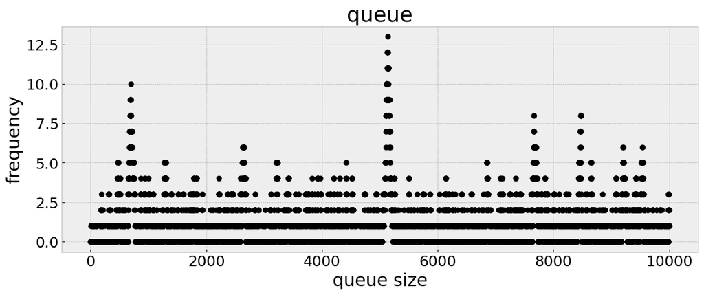

```
Worst delay: 13.0
```

```python
#(i) Arrivals smaller than service rate

trials = 10000
#p is previous section of p_opt_np while lambda is 0.02
p = p_e
q = p - 0.1

arrival = np.random.binomial(1, q, trials)
service = np.random.binomial(1, p, trials)

queue = np.zeros(trials+1)

for i in range(trials):
    if ((arrival[i]- service[i]) + queue[i] > 0):
        queue[i+1] = max(0, (arrival[i] - service[i]) + queue[i])

plt.figure(figsize=(14, 5))


plt.plot(queue, 'ok')
plt.xlabel('queue size')
plt.ylabel('frequency')
plt.title('queue')
plt.grid(True)
plt.show()
print(f'Worst delay: {np.max(queue)}')
```

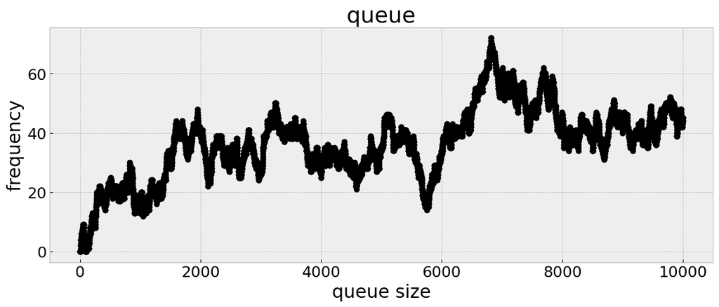

```
Worst delay: 72.0
```

```python
#(i) Arrival equal to Service rate

trials = 10000
#p is previous section of p_opt_np while lambda is 0.02
p = p_e
q = p

arrival = np.random.binomial(1, q, trials)
service = np.random.binomial(1, p, trials)

queue = np.zeros(trials+1)

for i in range(trials):
    if ((arrival[i]- service[i]) + queue[i] > 0):
        queue[i+1] = max(0, (arrival[i] - service[i]) + queue[i])

plt.figure(figsize=(14, 5))


plt.plot(queue, 'ok')
plt.xlabel('queue size')
plt.ylabel('frequency')
plt.title('queue')
plt.grid(True)
plt.show()

print(f'Worst delay: {np.max(queue)}')
```

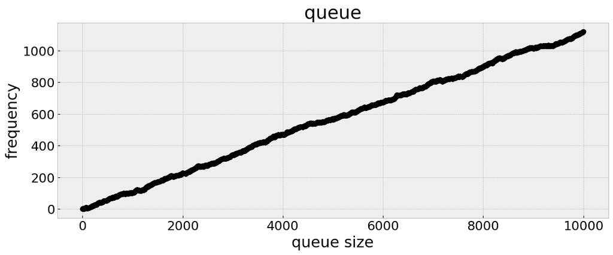

```
Worst delay: 1120.0
```

```python
#(i) Arrivals greater than service rate

trials = 10000
#p is previous section of p_opt_np while lambda is 0.02
p = p_e
q = p + 0.1

arrival = np.random.binomial(1, q, trials)
service = np.random.binomial(1, p, trials)

queue = np.zeros(trials+1)

for i in range(trials):
    if ((arrival[i]- service[i]) + queue[i] > 0):
        queue[i+1] = max(0, (arrival[i] - service[i]) + queue[i])

plt.figure(figsize=(14, 5))


plt.plot(queue, 'ok')
plt.xlabel('queue size')
plt.ylabel('frequency')
plt.title('queue')
plt.grid(True)
plt.show()
print(f'Worst delay: {np.max(queue)}')
```

As we can see that in the third figure, the queue increases linearly. So the best scenario is that p should be greater than q as the first figure shows as a proof.

(F) Write a short comment about what would you expect to happen with the queue of the TXs if:

- Restransmissions are allowed

  If Retransmissions are allowed, the queue size will increase due to failed packets are dropped. In addition, the failed packet will occupy another Tx slot to send which will prevent other packets from leaving the queue.
- CSMA protocol is used

  If CSMA protocol is used, it can help in avoiding collisions, potentially preventing the queue from growing indefinitely.
- Queues have a limited size

  If the queues have a limited size then the packets will be dropped if the queue size is greater than the worst delay. For example, in scenarios where q is significant greater than p, the queues might experience packet drops due to overflow.